# Raport z badania klinicznego WTM2020

Dr. med. W. Francuzik

25.05.2020

```r
# Load packages
pacman::p_load(tidyverse, here, ggpubr,chron,data.table)

# Load data cleanded from 1_data_cleaning
df <- read_rds(here("analysis/data/raw_data/clean_df.Rds"))
data <- df$data %>% filter(record_id %in% names(df$json_data))
start <- data %>% filter(redcap_event_name=="initial_visit_arm_1")
end <- data %>% filter(redcap_event_name=="end_of_study_visit_arm_1")
output <- df$output
json_data <- df$json_data
mean_frame <- df$mean_frame # srednie różnice miedzy sensorem a manualem
mean_frame$id <- rownames(mean_frame)
comp <- bind_rows(lapply(output, `[`, c(1))) #wszystkie wartosci manual/sensor
comp <- comp$comp
compare_frame <- bind_rows(lapply(output, `[`, c(2))) # srednie temperatury sensora dla kazdego pacjenta(json)
compare_frame <- compare_frame$comp_mean
rownames(compare_frame) <- names(json_data)
names_json <- names(json_data)
final_df <- list()
```

# Demografia

W badaniu wzięło udział 52 pacjentów oddziału chirurgicznego, którzy po wyrażeniu pisemnej świadomej i poinformowanej zgody na badanie zostali wyposażeni w czujnik temperatury WARMIE umieszczony w jeden z predefiniowanych lokalizacji: a) ramię, b) nadgarstek, c) udo, d) klatka piersiowa.

```r
#Years old
start %>% summarise(mean_age=mean(years_old))
```

```
##   mean_age
## 1 54.61538
```

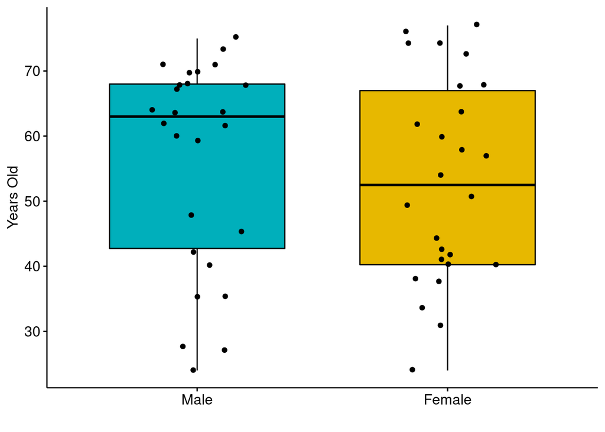

Wiek i płeć pacjentów właczonych do badania.

```r
ggboxplot(start, "gender.factor", "years_old",
      xlab="",ylab="Years Old",
      fill = "gender.factor",
      palette = c("#00AFBB", "#E7B800"),
      add ="jitter")+
  theme(legend.position = "none")
```

## Pomiar termometrem referencyjnym

U pacjentów przeprowadzono pomiar temperatury przy pomocy bezdotykowego termometra - pomiar na skroni, standard stosowany na oddziale chirurgicznym. Poniższe wykresy ilustrują histogram pomiarów temperatury u tych pacjentów przy pomocy standardowego termometra

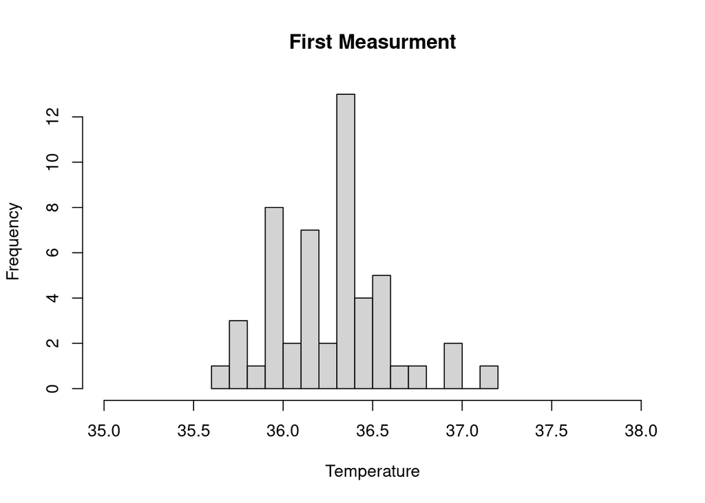

```r
hist(breaks = 20,end$patient_temperature,xlim=c(35,38),main="First Measurment",xlab="Temperature")
```

Takich pomiarów termometrem referencyjnym wykonano między 3-6, co 12 godzin.

# Pomiar czujnikiem Warmie

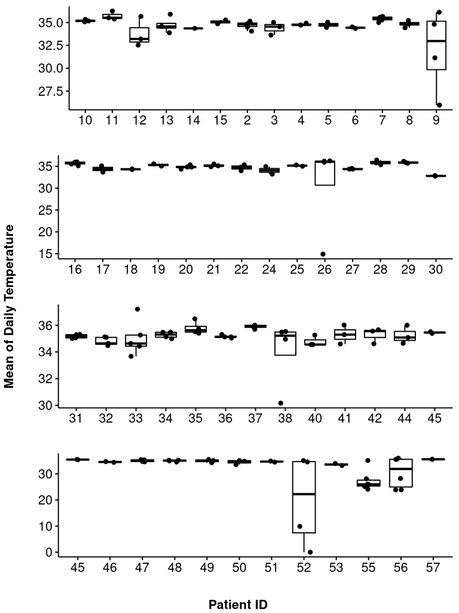

Średnia dzienna temperatura mierzona przez czujnik Warmie

```r
## Describe the dataset in general. How many patients we have and what we see

daily_fun <- function(pacjent) {
  daily <- output[[pacjent]]$full_table
  daily <- daily %>% group_by(day) %>% summarise(mean_daily=mean(value,na.rm=T),sd_daily=sd(value,na.rm = T))
  daily <- daily %>% as.data.frame()
  return(daily)
}
daily_stats <- map(names_json,daily_fun)
names(daily_stats) <- names_json
daily_stats <- plyr::ldply(daily_stats, data.frame)
daily_stats <- daily_stats %>% rename(id=.id)

#Daily Mean, to find patients different from the norm

daily_mean_plot <-ggarrange(
ggboxplot(daily_stats, "id", "mean_daily",
          select = c(1:15),xlab="",ylab="",
          add = "jitter"),
ggboxplot(daily_stats, "id", "mean_daily",
          select = c(16:30),xlab="",ylab="",
          add = "jitter"),
ggboxplot(daily_stats, "id", "mean_daily",
          select = c(31:45),xlab="",ylab="",
          add = "jitter"),
ggboxplot(daily_stats, "id", "mean_daily",
          select = c(45:60),xlab="",ylab="",
          add = "jitter"),ncol=1)
annotate_figure(daily_mean_plot,
                bottom = text_grob("Patient ID", color = "black", face = "bold", size = 12),
                left = text_grob("Mean of Daily Temperature", color = "black",face="bold", rot = 90))
```

Na powyższym wykresie widać że pomiary dobowe były spójne u większości pacjentów. U pacjenta 9, 26, 52, 56 średnie dobowe miały bardzo duży rozrzut i dlatego muszą zostać krytycznie zanalizowane. U tych pacjentów wachania w średnivh dobowych polegają najprawdopodobniej na częstszym zdejmowaniu czujnika z miejsca pomiaru.

Poniżej wykres odchylenia standardowego w tych samych pomiarach

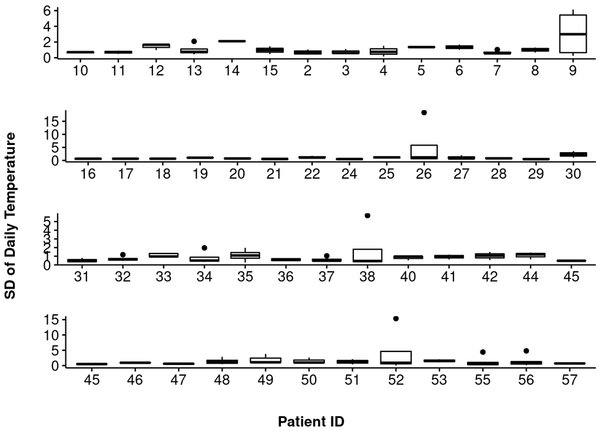

```r
#Daily SD, to see the cyclicality of temperatures( if a large dispersion can be determined the absence of cyclicality)

daily_sd_plot <-ggarrange(
  ggboxplot(daily_stats, "id", "sd_daily",
            select = c(1:15),xlab="",ylab=""),
  ggboxplot(daily_stats, "id", "sd_daily",
            select = c(16:30),xlab="",ylab=""),
  ggboxplot(daily_stats, "id", "sd_daily",
            select = c(31:45),xlab="",ylab=""),
  ggboxplot(daily_stats, "id", "sd_daily",
            select = c(45:60),xlab="",ylab=""),ncol=1)
annotate_figure(daily_sd_plot,
                bottom = text_grob("Patient ID", color = "black", face = "bold", size = 12),
                left = text_grob("SD of Daily Temperature", color = "black",face="bold", rot = 90))
```

# Różnice w pomiarach temp między warmie a termometrem referencyjnym

Optymalnie różnicepomiarowe powinny być jak najnmniejsze. Widzimy na poniższym wykresie że u niektórych pacjentów były one dramatycznie wysokie - co prawdopodobnie nie jst zależne od sensora warmie, lecz od nieprawidłowego udokumentowania czasu pomiaru przy pomocy termometra referencyjnego (lub braku umieszczenia czujnika Warmie na skórzy kiedy wykoanany został pomiar termometrem referencyjnym).

Widzimy, że u pacjenta nr 52 różnica w pomiarach była jednorazowo ponad 30 stopni, co sugeruje że w momencie pomiaru czuujnik warmie nie był założony.

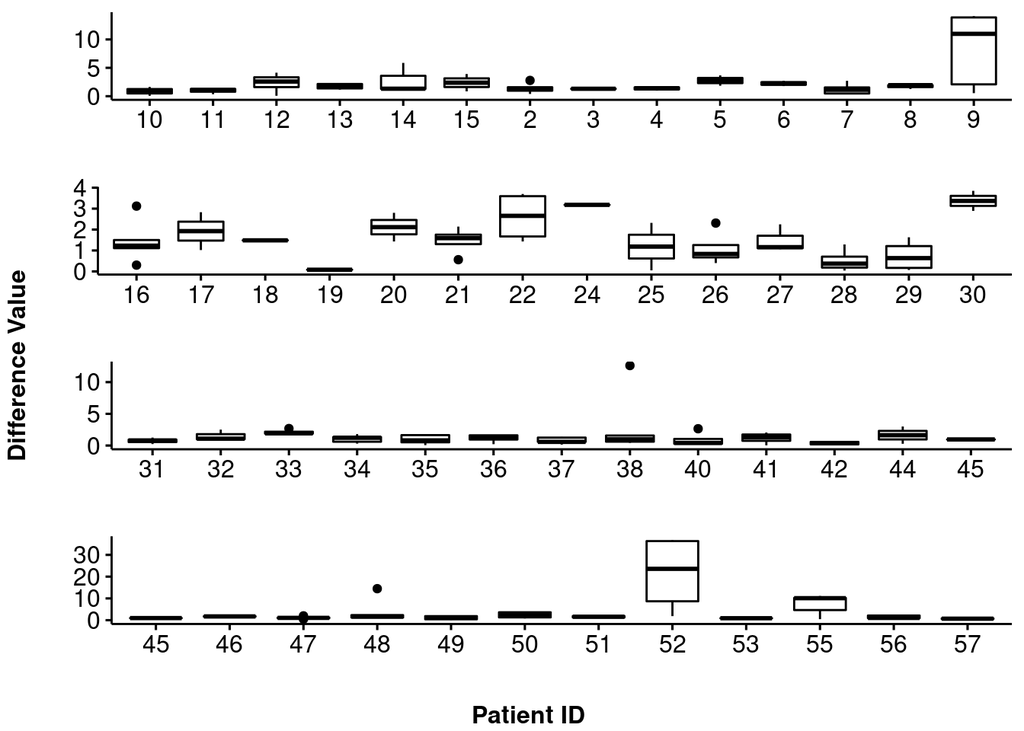

Różnice pomiarowe w pomiarach czujnika Warmie względem termometra referencyjnego.

```r
#Mean difference manual/sensor per patient

mean_diff_plot <-ggarrange(
  ggboxplot(comp, "id", "diff_value",
            select = c(1:15),xlab="",ylab=""),
  ggboxplot(comp, "id", "diff_value",
            select = c(16:30),xlab="",ylab=""),
  ggboxplot(comp, "id", "diff_value",
            select = c(31:45),xlab="",ylab=""),
  ggboxplot(comp, "id", "diff_value",
            select = c(45:60),xlab="",ylab=""),ncol=1)
annotate_figure(mean_diff_plot,
                bottom = text_grob("Patient ID", color = "black", face = "bold", size = 12),
                left = text_grob("Difference Value", color = "black",face="bold", rot = 90))
```

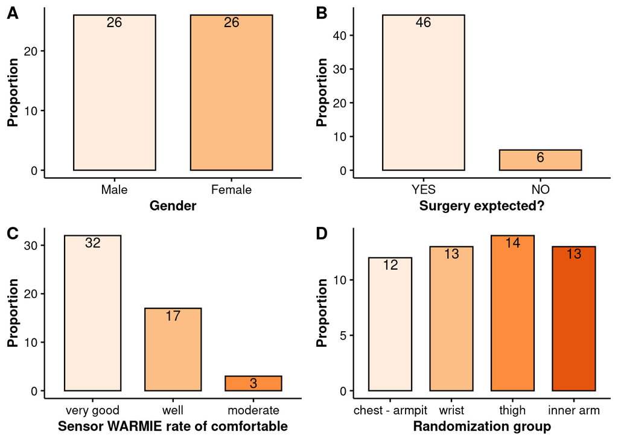

```r
barplot_fun <- function(data,var,namex){
  var <- enquo(var)
  data <- data %>% rename(x=!!var)
a <- data %>%
  group_by(x) %>%
  count() %>%
  ggpubr::ggbarplot(
    x = "x",
    fill = "x",
    y = "n",
    label = TRUE, lab.col = "black", lab.vjust = 1.2,
    position = position_dodge2(),
    palette = get_palette(palette = "Oranges",5),
  )+labs(x=namex,y="Proportion")+
  font("xy.text", size = 10, color = "black")+
  theme(legend.position = "none")


a <- ggpar(a,
               font.x = c(11, "bold"),
               font.y = c(11, "bold"),
               font.legend = c(9,"bold"))
return(a)
}

ggarrange(
barplot_fun(start,gender.factor,"Gender"),
barplot_fun(start,surgery.factor,"Surgery exptected?"),
barplot_fun(end,comfort.factor,"Sensor WARMIE rate of comfortable"),
barplot_fun(start,random.factor,"Randomization group"),
labels = (LETTERS[1:4])
)
```

```r
#hist(start$years_old,ylim=c(0,20),col="lightblue",main = "Years old Histogram", xlab = "Years old")

#mean_frame %>% summarise(mean=mean(mean,na.rm = T),sd_error=mean(sd_error))
#compare_frame %>% summarise(min=min(min_temp),max=max(max_temp),mean=mean(mean_temp),sd=mean(sd_temp))
```

# Wykresy pomiarowe u poszczególnych pacjentów

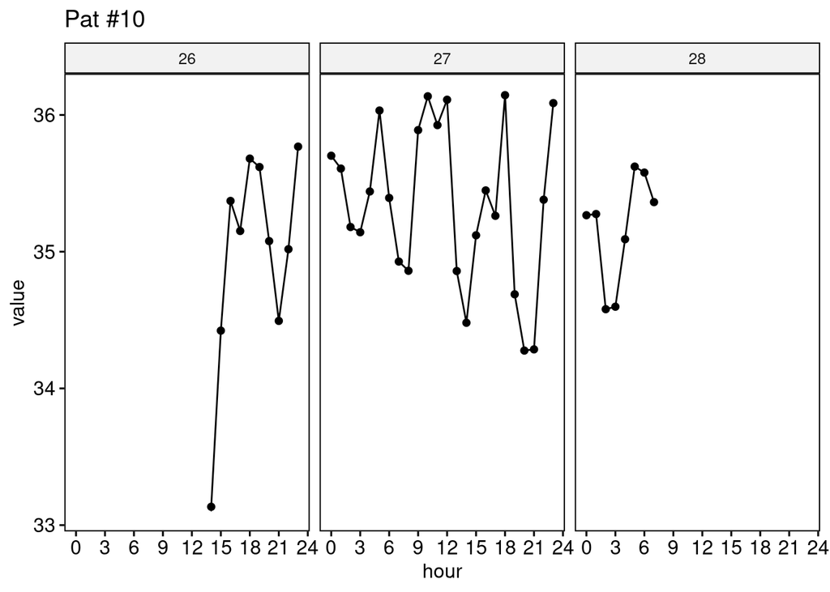

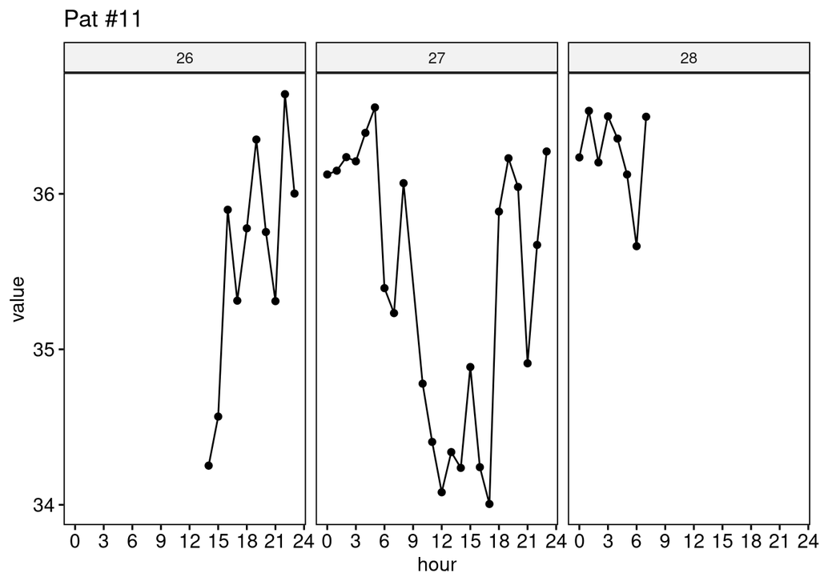

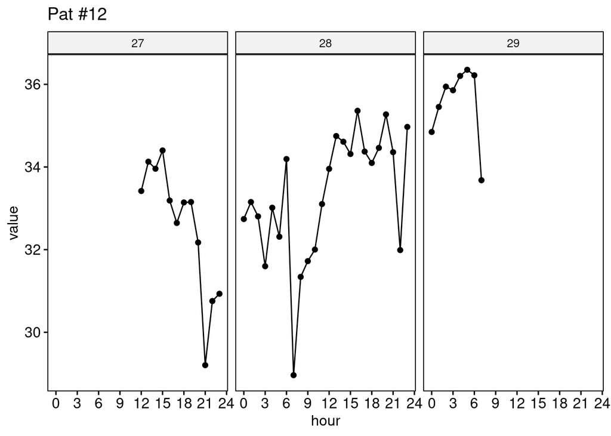

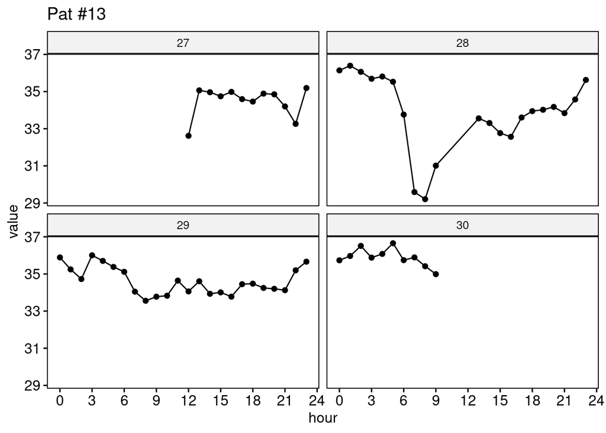

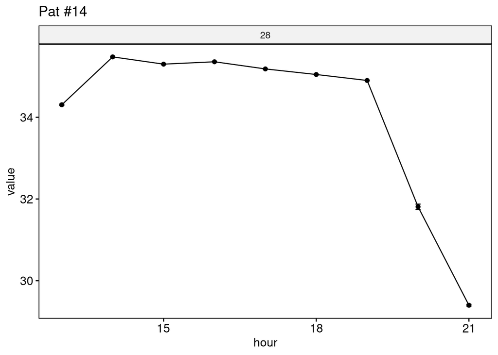

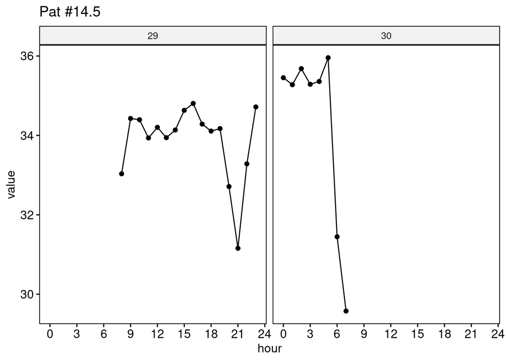

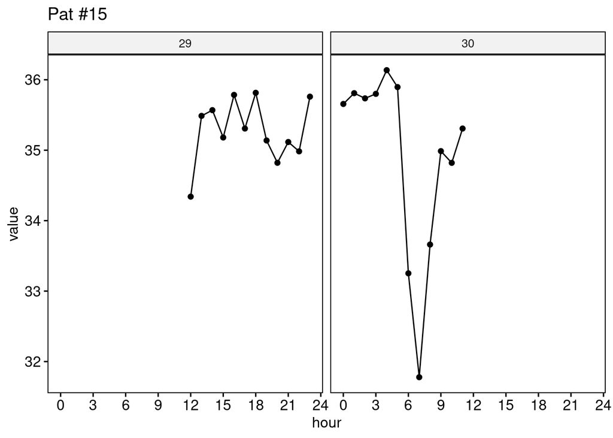

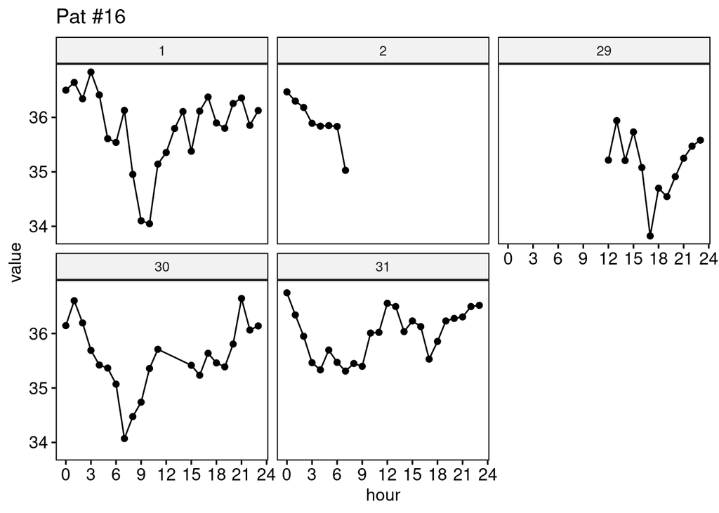

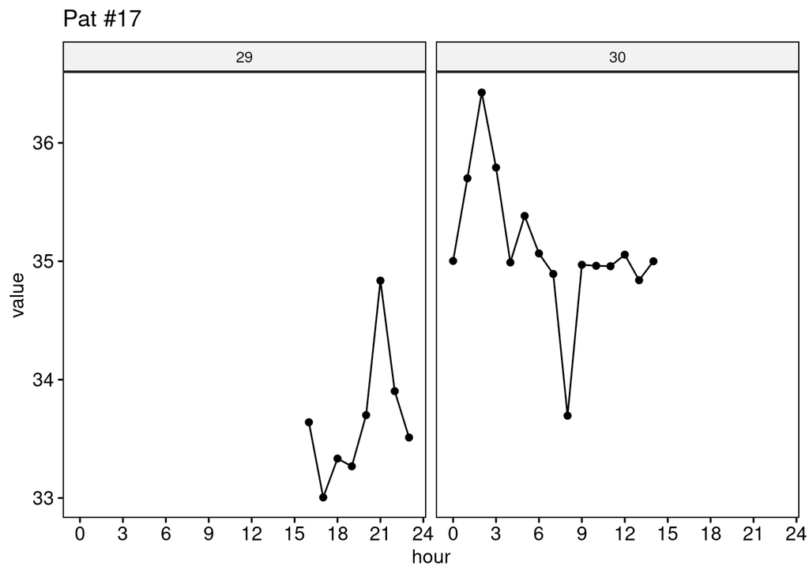

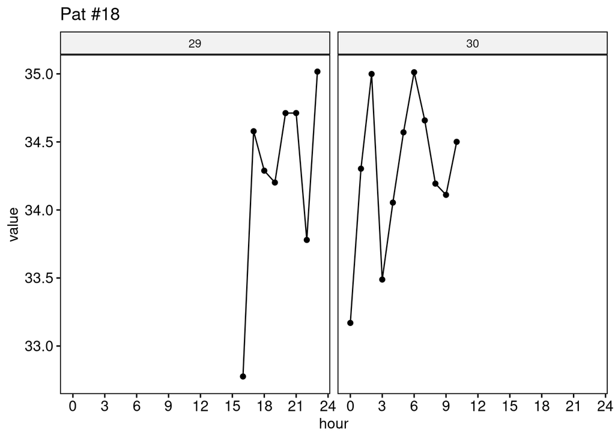

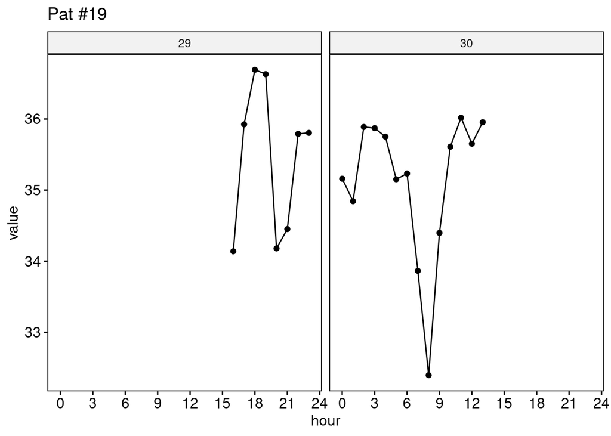

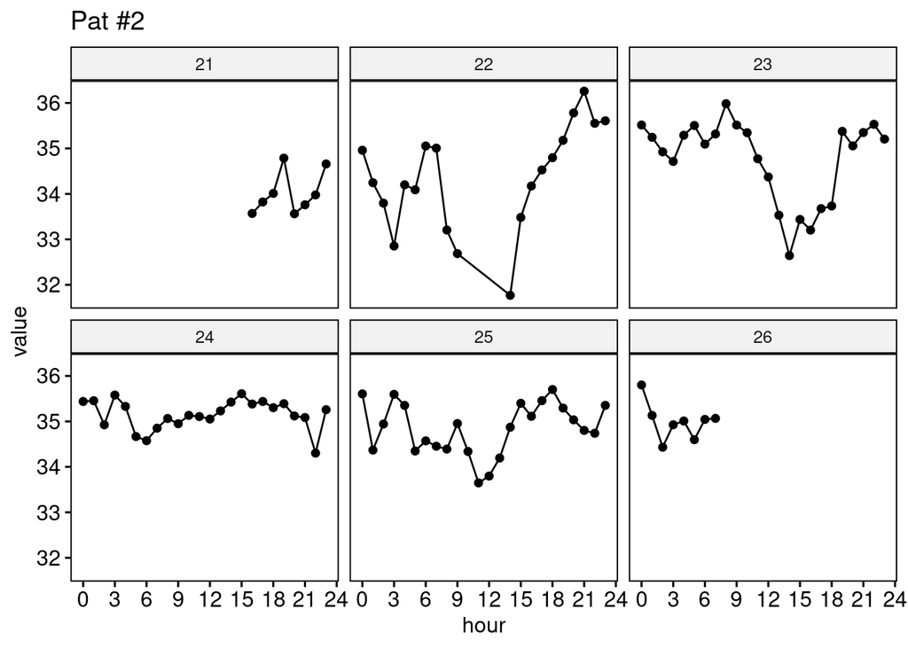

[42 more figures not shown]

```r
map(names(output),function(x){
  output[[x]]$plot+
    labs(title = paste0("Pat #", x))
})
```

# Podsumowanie

1. Na wykresach widoczne są dobowie wahania temperatury mierzonej przez sensor.
2. Temperatura podczas snu jest zwykle bardziej stabilna niż w dzień i lepiej nadaje się do monitorowania. 3. Temperatura podczas godzin porannych jest zwykle najniższ, co może być spowodowane porannym uwalnianiem kortyzonu, który powoduje centralizcję krążenia i tym samym niższą temperaturę skóry.

# Następne kroki

1. Następnym elementem analizy będzie zastosowanie algorytmów do automatycznej ekstrakcji zdarzeń (automatic feature extraction) z ciągłych pomiarów temperatury.
2. Weryfikacja użyteczości zastosowania metod analizy spectrum do oceny dobowych zmian temperatury.
3. Publikacja dancych w Journalu akademickim.